# Krankheiten im Rebbau - Erklärungen

Carolin Bronowicz

2021-05-20

Hier gehts zurück zur Übersicht

# Einführung

Die typischten Infektionskrankheiten, die in den Reben vorkommt sind: + Botrytis + Echter Mehltau + Falscher Mehltau

Diese entstehen und verbreiten sich primär dadurch, wenn es über einen längeren Zeitraum feucht ist. Aus diesem Wissen wurden Niederschlagsdaten verwendet um zu analysieren, ob mit Hilfe dieser Aussagen getroffen werden können, wie gross die Wahrscheinlichkeit ist, dass sich diese Krankheiten ausbreiten.

# Vorbereitung der Informationen

## KoboCollect Datensatz

Die gesammelten Daten wurden vom Server, die von der KoboToolBox zur verfügng gestellt wurde heruntergeladen und zur weiteren Verarbeitung vorbereitet.

| befallBlatt | krankheit | befallmenge | date | befallTraube | weintyp | foto_oben | betrieb | foto_rebe | befall_prozent | foto_unten | kommentar | parzelle | newdate |
| --- | --- | --- | --- | --- | --- | --- | --- | --- | --- | --- | --- | --- | --- |
| 1 | echter_mehltau | 80 | 2021-04-15T13:47:37.589+02:00 | 5 | sauvignon_blanc | NA | NA | NA | NA | NA | NA | NA | 15.04.2021 |
| 1 | schwarzholzkrankheit | 20 | 2021-04-06T16:50:00.000+02:00 | 2 | sauvignon_blanc | NA | NA | NA | NA | NA | NA | NA | 06.04.2021 |
| 2 | schwarzholzkrankheit | 20 | 2021-04-03T16:38:00.000+02:00 | 1 | chardonnay_ | NA | NA | NA | NA | NA | NA | NA | 03.04.2021 |
| 2 | esca | 40 | 2021-04-04T13:53:00.000+02:00 | 2 | chardonnay_ | NA | NA | NA | NA | NA | NA | NA | 04.04.2021 |
| NA | gar_keine | NA | 2021-04-04T13:54:00.000+02:00 | NA | malbec | NA | NA | NA | NA | NA | NA | NA | 04.04.2021 |
| 2 | botrytis | 20 | 2021-04-04T13:57:00.000+02:00 | 2 | riesling_sylvaner | 1617537427049.jpg | Test | NA | NA | NA | NA | NA | 04.04.2021 |

## Statistische Auswerungen

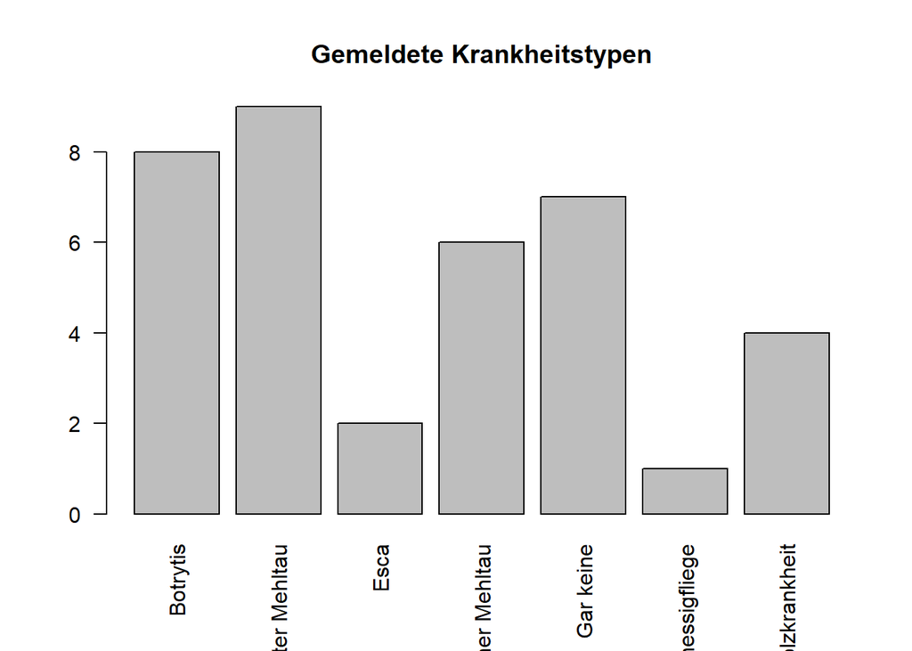

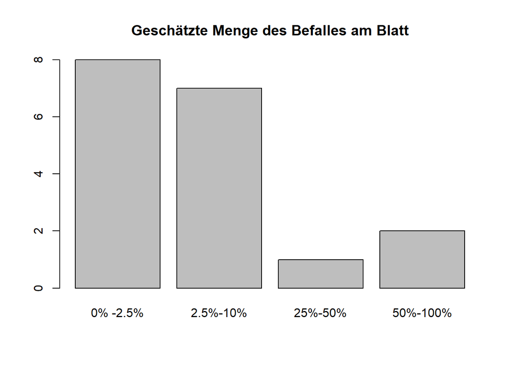

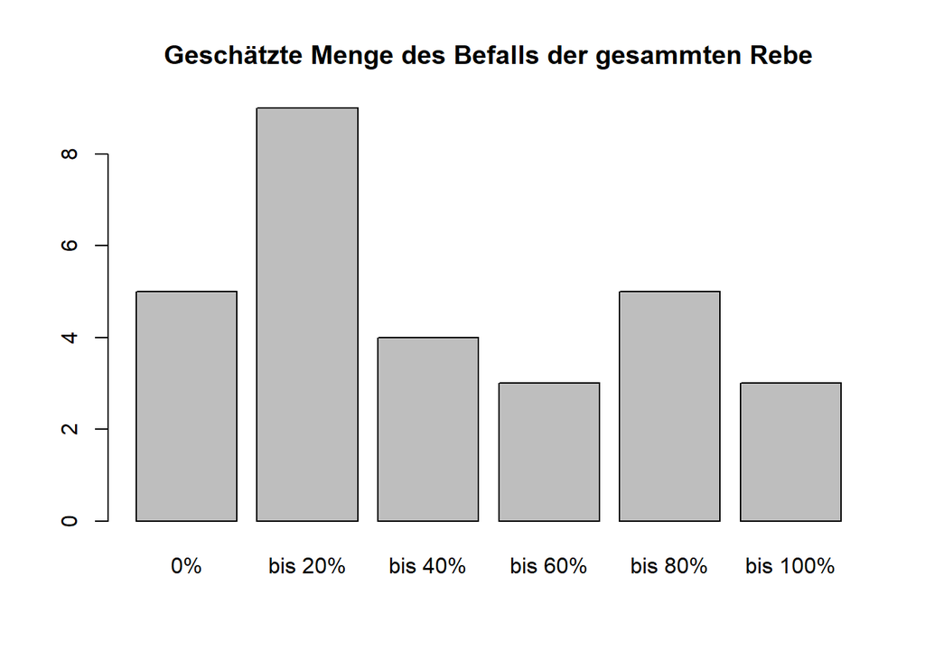

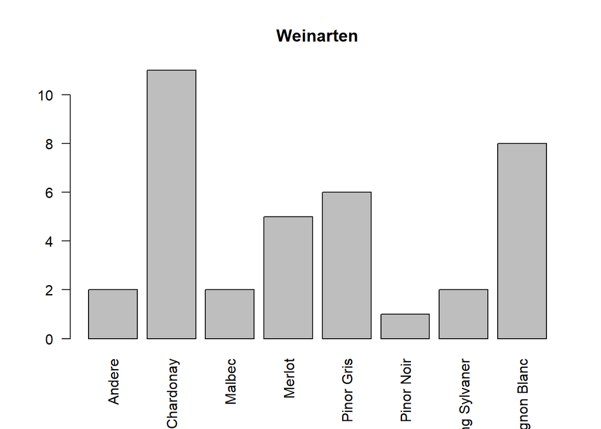

**Gesammte Anzahl gesammelter Informationen:** 37

# Wetterkarte (letzte 10-Minuten)

## Niederschlag Datensatz

Um dem Nutzer die Möglichkeit zu geben die aktuellen Niederschlagswerte anzuschauen wurden bei den 10-Min-aktuellen Daten, bereitgestelt durch geo.admin.ch angeknüpft.

| Station | Abk. | WIGOS.ID | Niederschlag.mm | Messdatum | Messhöhe.m..ü..M. | Zusatzinformation.m..ü..Boden | KoordinatenE | KoordinatenN | Breitengrad | Längengrad | Kanton | Link |
| --- | --- | --- | --- | --- | --- | --- | --- | --- | --- | --- | --- | --- |
| Aadorf / Tänikon | TAE | 0-20000-0-06679 | 0 | 2021-05-20 15:30 | 540 | 1.50 m | 2710513 | 1259817 | 47.47983 | 8.904853 | TG | https://www.meteoschweiz.admin.ch/home/messwerte.html?param=messwerte-niederschlag-10min&station=TAE |
| Acquarossa / Comprovasco | COM | 0-20000-0-06756 | 0 | 2021-05-20 15:30 | 576 | 1.50 m | 2714993 | 1146448 | 46.45949 | 8.935589 | TI | https://www.meteoschweiz.admin.ch/home/messwerte.html?param=messwerte-niederschlag-10min&station=COM |
| Adelboden | ABO | 0-20000-0-06735 | 0 | 2021-05-20 15:30 | 1323 | 1.50 m | 2609372 | 1148939 | 46.49170 | 7.560703 | BE | https://www.meteoschweiz.admin.ch/home/messwerte.html?param=messwerte-niederschlag-10min&station=ABO |
| Affoltern i. E. | AIE |  | 0 | 2021-05-20 15:30 | 757 | 1.50 m | 2622940 | 1212500 | 47.06312 | 7.740614 | BE | https://www.meteoschweiz.admin.ch/home/messwerte.html?param=messwerte-niederschlag-10min&station=AIE |
| Aigle | AIG | 0-20000-0-06712 | 0 | 2021-05-20 15:30 | 382 | 1.50 m | 2560400 | 1130711 | 46.32662 | 6.924425 | VD | https://www.meteoschweiz.admin.ch/home/messwerte.html?param=messwerte-niederschlag-10min&station=AIG |
| Airolo | AIR | 0-756-0-AIR | 0 | 2021-05-20 15:30 | 1141 | 2.00 m | 2688910 | 1153400 | 46.52599 | 8.597444 | TI | https://www.meteoschweiz.admin.ch/home/messwerte.html?param=messwerte-niederschlag-10min&station=AIR |

## Darstellung der Stationen

Zunächst wurden die verfügbaren Stationen visualisiert, die uns regelmässig Daten liefern können. Da die Niederschlagsdaten nur jeweils die Niederschlagswerte an den Stationen wiedergeben wurde eine interpolierte Karte erstellt

```
## [inverse distance weighted interpolation]
```

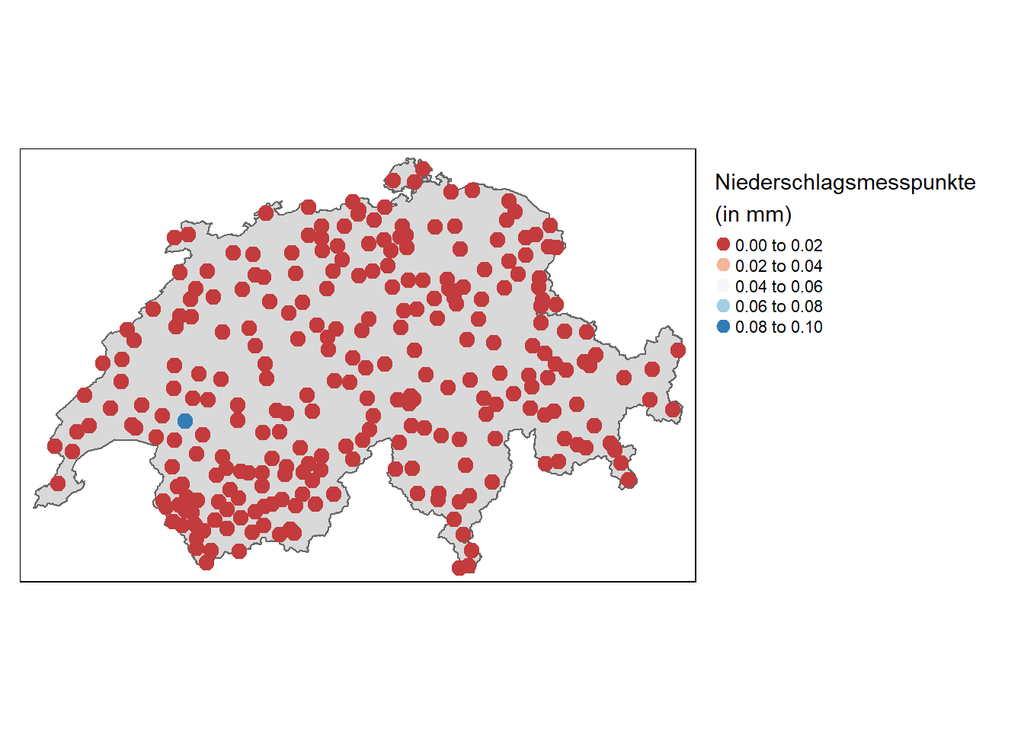

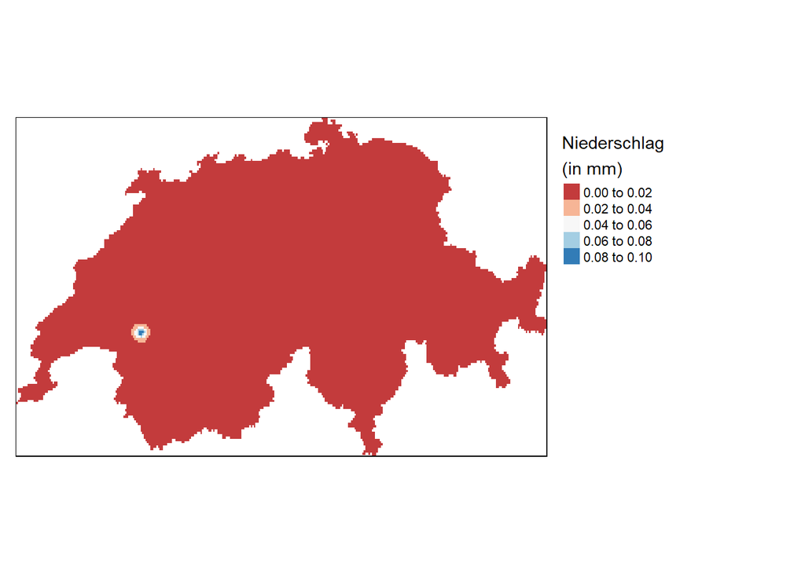

## Interaktive Karte (letzte 10-minuten)

Niederschlagsdaten zusammen mit den gesammelten Daten

[interactive chart not shown]

# Niederschlagskarte kummuliert 7 Tage

```
## [inverse distance weighted interpolation]
```

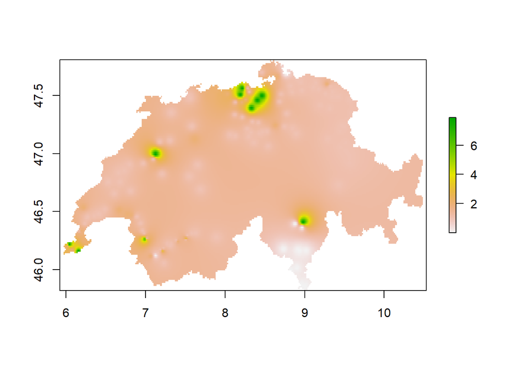

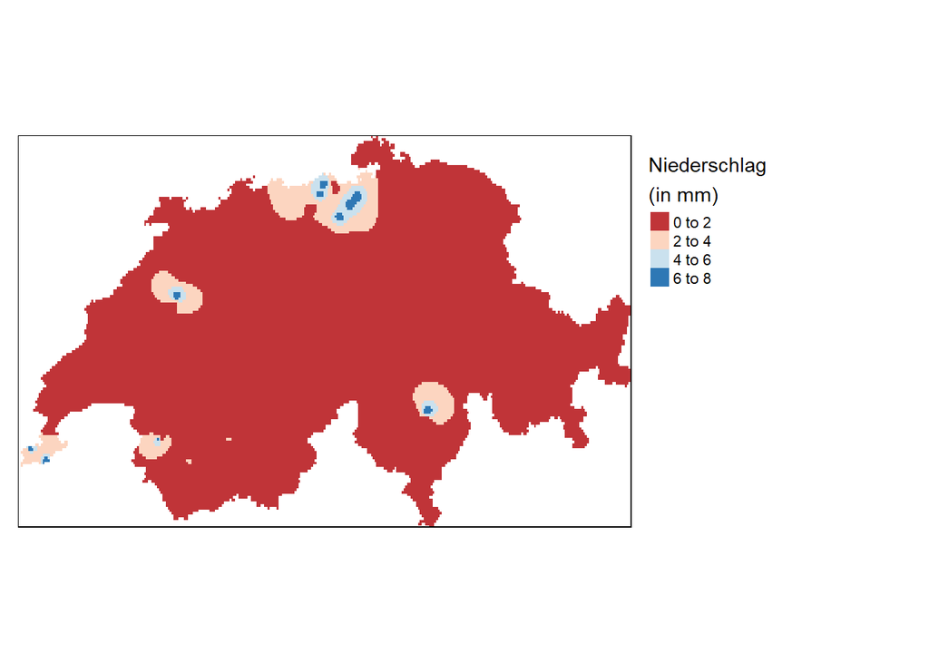

## Interaktive Karte (7 Tage kummuliert)

[interactive chart not shown]

# Parzellen: Infektionen und Bekämpfungsstrategien

In den folgenden zwei wurde exemplarisch für zwei verschiedene Standorte die Möglichkeit aufgezeigt, Informationen zu den Parzellengrenzen hinzuzufügen. Bei der Aufnahme der Informationen über die KoboCollect App können auch Angaben z.B. zu Pflanzenschutzstrategien gemacht werden. Diese werden dann mit den Parzellen verglichen und der jeweiligen Parzelle wird die entsprechende Strategie zugewiesen. Dadurch kann über die Zeit werden abgeglichen, welche Strategie erfolgreicher für welche Weinsorte ist. Dies soll dem Winzer die Möglichkeit geben, mit hilfe dieser Informationen seine Strategien anzupassen. Falls keine Informationen zu den Strategien vorhanden sind, können auch die verschiedene Weintypen, die in den Parzellen vorhanden sind, visualisiert werden.

## Haegglingen

[interactive chart not shown]

## Klus177

[interactive chart not shown]

# Krankheitsmodelle

## Graufäule (Botrytis)

[figure not shown]

## Mehltau

[figure not shown]